# Part II - Airline on-Time Performance Data Analysis Presentation

## by Joseph Ebere

## 1.1 Investigation Overview

> In this investigation, I wanted to look at the features of the dataset with which flights delays and cancellation can be predicted. The main focus was on Cancellation and its distribution (percentage) and the day(s) of the week that have the highest rate of delays and cancellation, in order to predict the most convenient days of travel by flight.

## 1.2 Dataset Overview

> The dataset name is "Airline On-Time Performance Data". This dataset reports flights in the United States, including carriers, arrival and departure delays, and reasons for delay. The dataset has records for year 1987 to 2022, but for this investigation, only year 1987 was considered.

## 1.3 Distribution of flight Cancellation

> The distribution of flight cancellation, gotten by the value count of the feature, was plotted on a bar chart. The chart shows us that there was a 1.5% flight cancellation and 98.5% of No-Cancellation during the year 1987.

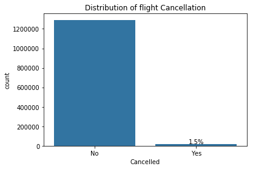

### 1.4 Arrival Delay by Distance

> Arrival delay tells us the additional time from the scheduled time it took a flight to arrive. The distance shows the distance travelled by the flight. The scatter plot shows us that there is no relationship between the distance travelled and the arrival delay.

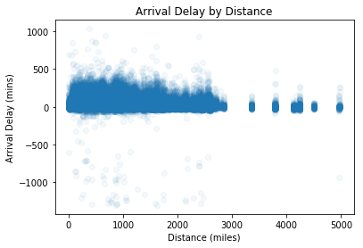

## 1.5 Departure Delay by Distance

> Departure delay tells us the additional time from the scheduled time it took a flight to depart. The distance shows the distance travelled by the flight. The scatter plot shows us that there is no relationship between the distance travelled and the departure delay.

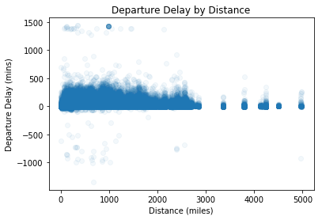

## 1.6 Arrival Delay, Departure Delay by Day of Week

[figure not shown]